# White Wine Exploration by Elisa Marchione

This project explores a dataset that contains 4,898 white wines.

# Univariate Plots Section

There are 11 variables that quantify the chemical properties of the wine. There is a rating for each wine between 0 (very bad) and 10 (very excellent), averaged from at least 3 wine experts.

```
##  [1] "X"                    "fixed.acidity"        "volatile.acidity"
##  [4] "citric.acid"          "residual.sugar"       "chlorides"
##  [7] "free.sulfur.dioxide"  "total.sulfur.dioxide" "density"
## [10] "pH"                   "sulphates"            "alcohol"
## [13] "quality"
```

This data set was already cleaned up, so the data types are appropriate so far.

```
## 'data.frame':    4898 obs. of  13 variables:
##  $ X                   : int  1 2 3 4 5 6 7 8 9 10 ...
##  $ fixed.acidity       : num  7 6.3 8.1 7.2 7.2 8.1 6.2 7 6.3 8.1 ...
##  $ volatile.acidity    : num  0.27 0.3 0.28 0.23 0.23 0.28 0.32 0.27 0.3 0.22 ...
##  $ citric.acid         : num  0.36 0.34 0.4 0.32 0.32 0.4 0.16 0.36 0.34 0.43 ...
##  $ residual.sugar      : num  20.7 1.6 6.9 8.5 8.5 6.9 7 20.7 1.6 1.5 ...
##  $ chlorides           : num  0.045 0.049 0.05 0.058 0.058 0.05 0.045 0.045 0.049 0.044 ...
##  $ free.sulfur.dioxide : num  45 14 30 47 47 30 30 45 14 28 ...
##  $ total.sulfur.dioxide: num  170 132 97 186 186 97 136 170 132 129 ...
##  $ density             : num  1.001 0.994 0.995 0.996 0.996 ...
##  $ pH                  : num  3 3.3 3.26 3.19 3.19 3.26 3.18 3 3.3 3.22 ...
##  $ sulphates           : num  0.45 0.49 0.44 0.4 0.4 0.44 0.47 0.45 0.49 0.45 ...
##  $ alcohol             : num  8.8 9.5 10.1 9.9 9.9 10.1 9.6 8.8 9.5 11 ...
##  $ quality             : int  6 6 6 6 6 6 6 6 6 6 ...
```

First of all, I want to see the distribution of the quality scores for all the white wines.

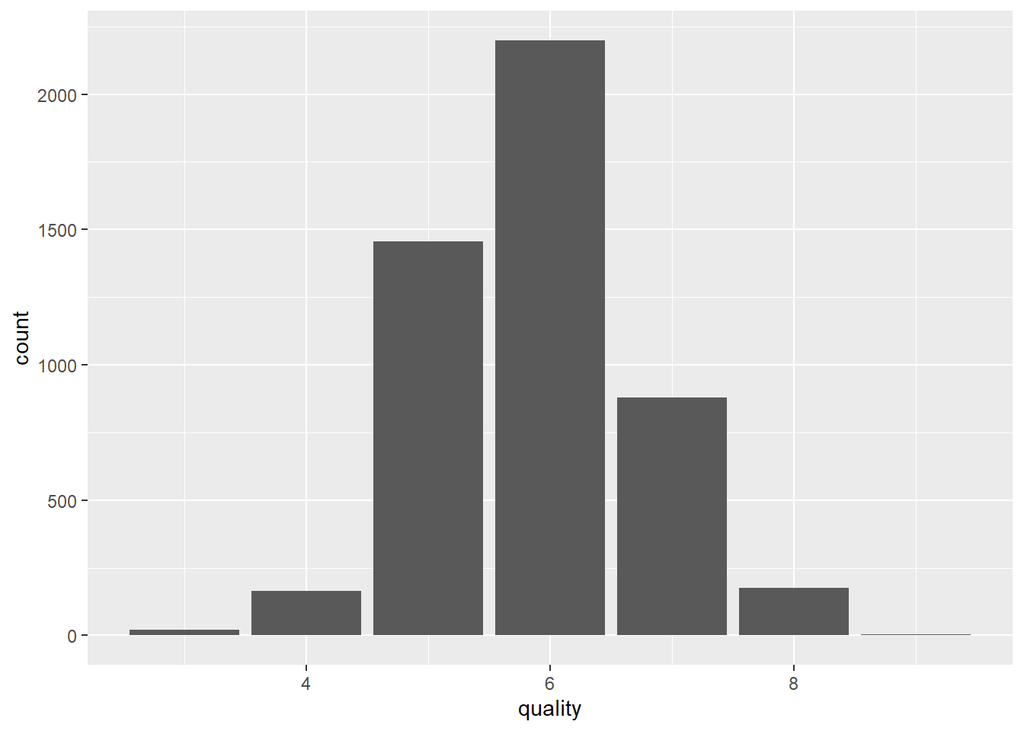

```
##    Min. 1st Qu.  Median    Mean 3rd Qu.    Max.
##   3.000   5.000   6.000   5.878   6.000   9.000
```

It appears to have a normal distribution, with 6 being the most common score.

Our guiding question with this dataset is to determine which chemical properties influence the quality of white wines. I’ll start out by running some summary statistics to look for any variables that stand out.

```
##        X        fixed.acidity    volatile.acidity  citric.acid
##  Min.   :   1   Min.   : 3.800   Min.   :0.0800   Min.   :0.0000
##  1st Qu.:1225   1st Qu.: 6.300   1st Qu.:0.2100   1st Qu.:0.2700
##  Median :2450   Median : 6.800   Median :0.2600   Median :0.3200
##  Mean   :2450   Mean   : 6.855   Mean   :0.2782   Mean   :0.3342
##  3rd Qu.:3674   3rd Qu.: 7.300   3rd Qu.:0.3200   3rd Qu.:0.3900
##  Max.   :4898   Max.   :14.200   Max.   :1.1000   Max.   :1.6600
##  residual.sugar     chlorides       free.sulfur.dioxide total.sulfur.dioxide
##  Min.   : 0.600   Min.   :0.00900   Min.   :  2.00      Min.   :  9.0
##  1st Qu.: 1.700   1st Qu.:0.03600   1st Qu.: 23.00      1st Qu.:108.0
##  Median : 5.200   Median :0.04300   Median : 34.00      Median :134.0
##  Mean   : 6.391   Mean   :0.04577   Mean   : 35.31      Mean   :138.4
##  3rd Qu.: 9.900   3rd Qu.:0.05000   3rd Qu.: 46.00      3rd Qu.:167.0
##  Max.   :65.800   Max.   :0.34600   Max.   :289.00      Max.   :440.0
##     density             pH          sulphates         alcohol
##  Min.   :0.9871   Min.   :2.720   Min.   :0.2200   Min.   : 8.00
##  1st Qu.:0.9917   1st Qu.:3.090   1st Qu.:0.4100   1st Qu.: 9.50
##  Median :0.9937   Median :3.180   Median :0.4700   Median :10.40
##  Mean   :0.9940   Mean   :3.188   Mean   :0.4898   Mean   :10.51
##  3rd Qu.:0.9961   3rd Qu.:3.280   3rd Qu.:0.5500   3rd Qu.:11.40
##  Max.   :1.0390   Max.   :3.820   Max.   :1.0800   Max.   :14.20
##     quality
##  Min.   :3.000
##  1st Qu.:5.000
##  Median :6.000
##  Mean   :5.878
##  3rd Qu.:6.000
##  Max.   :9.000
```

The variables that stand out to me at first are the ones that have a wide range between min and max, such as residual.sugar, free.sulfur.dioxide, and total.sufur.dioxide. I’ll run some quick histograms to see the distributions.

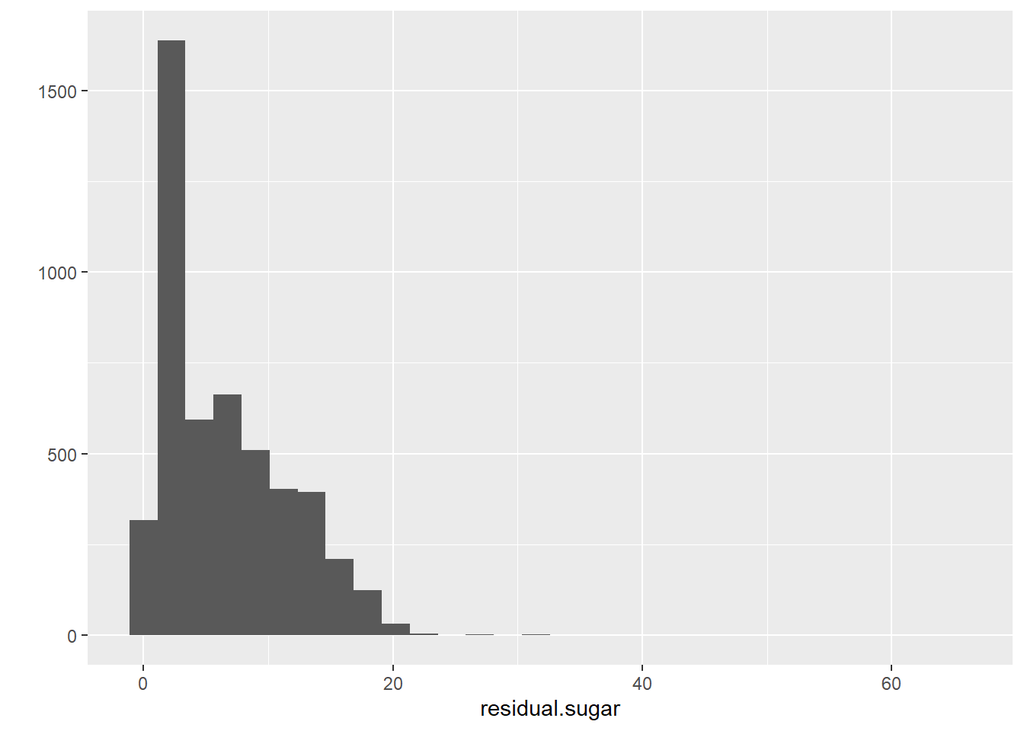

I’m limiting the data to see the bulk of the information, as well as updating the bin width to 1 so I can get a better idea of the distribution.

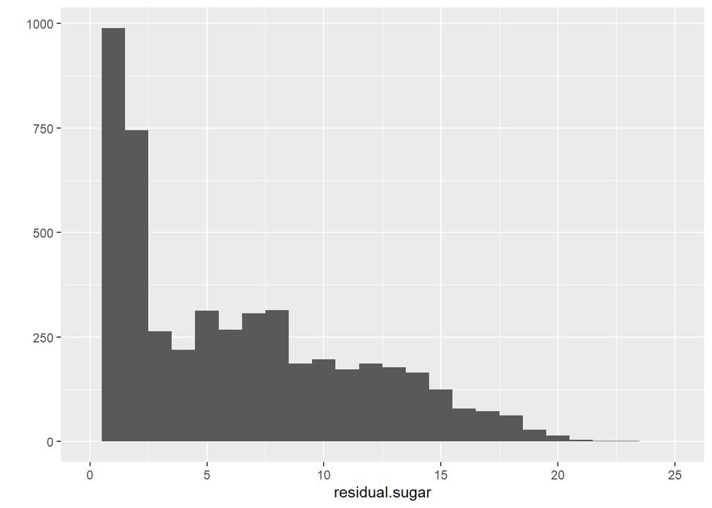

It appears that residual.sugar is right-skewed, with most of the values being very low.

Domain research has determined that residual.sugar actually determines the type of wine. I realized that I could create a new variable called type from the residual.sugar value and create a categorical value that might be useful for further analysis.

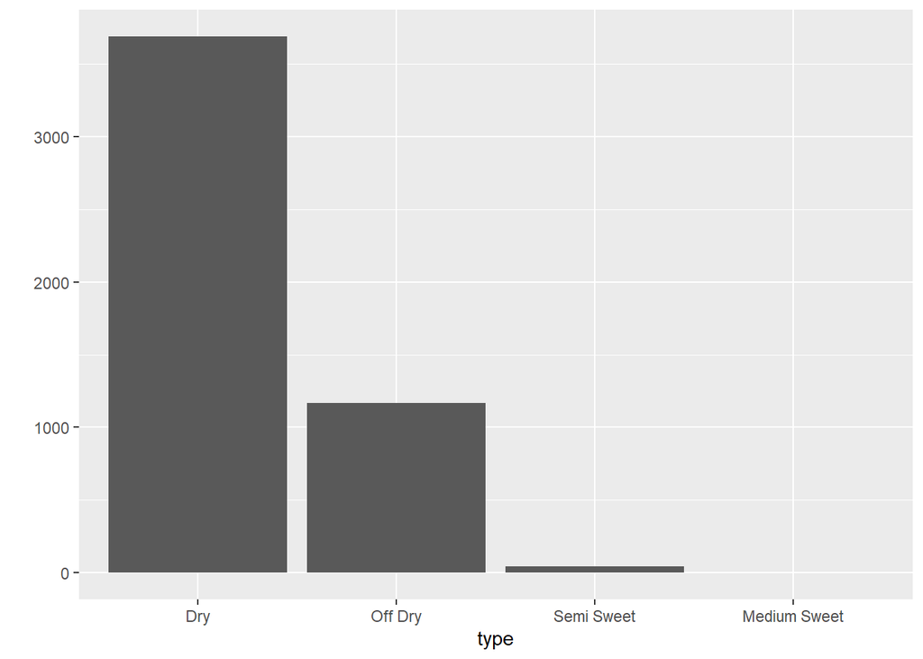

It appears that a large majority of the wines studied were considered dry and off dry.

I want to see how some of the other statistics are distributed.

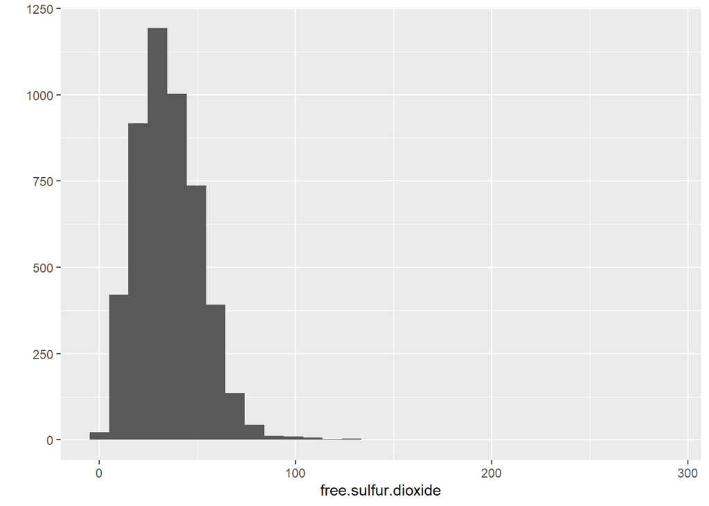

Free.sulfur.dioxide appears to have a normal distribution.

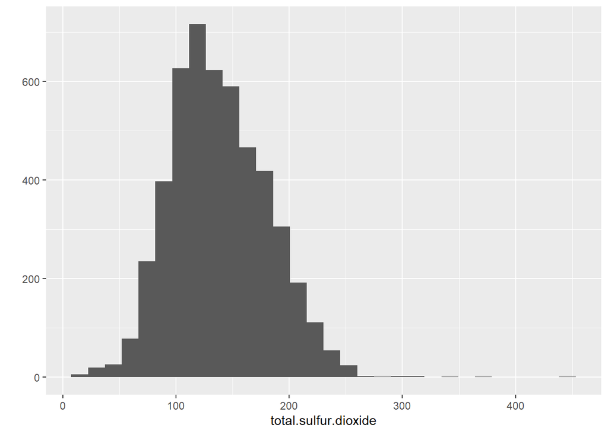

Total.sufulr.dioxide also appears to have a normal distribution.

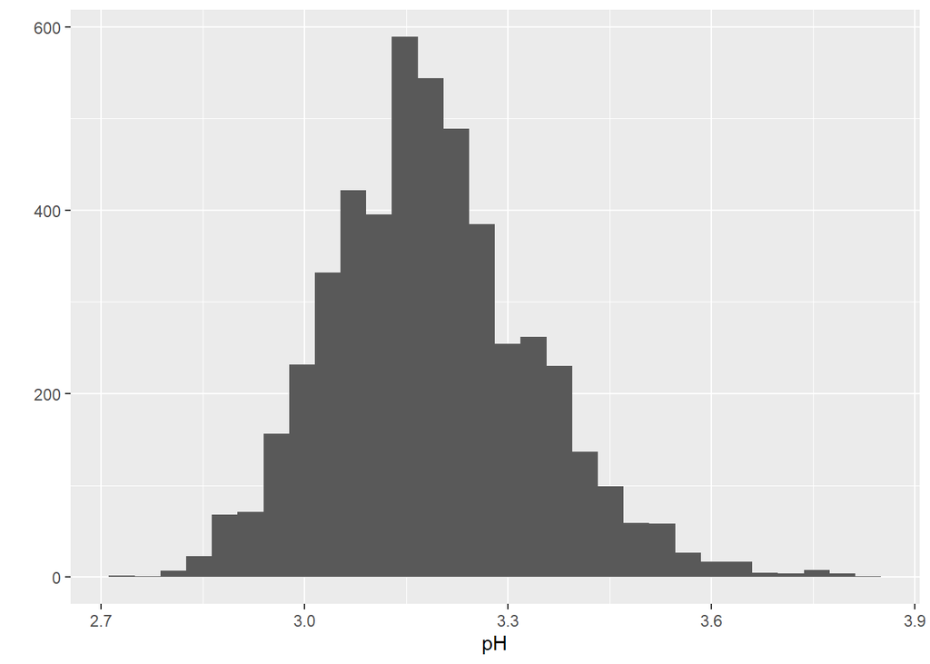

pH has a normal distribution.

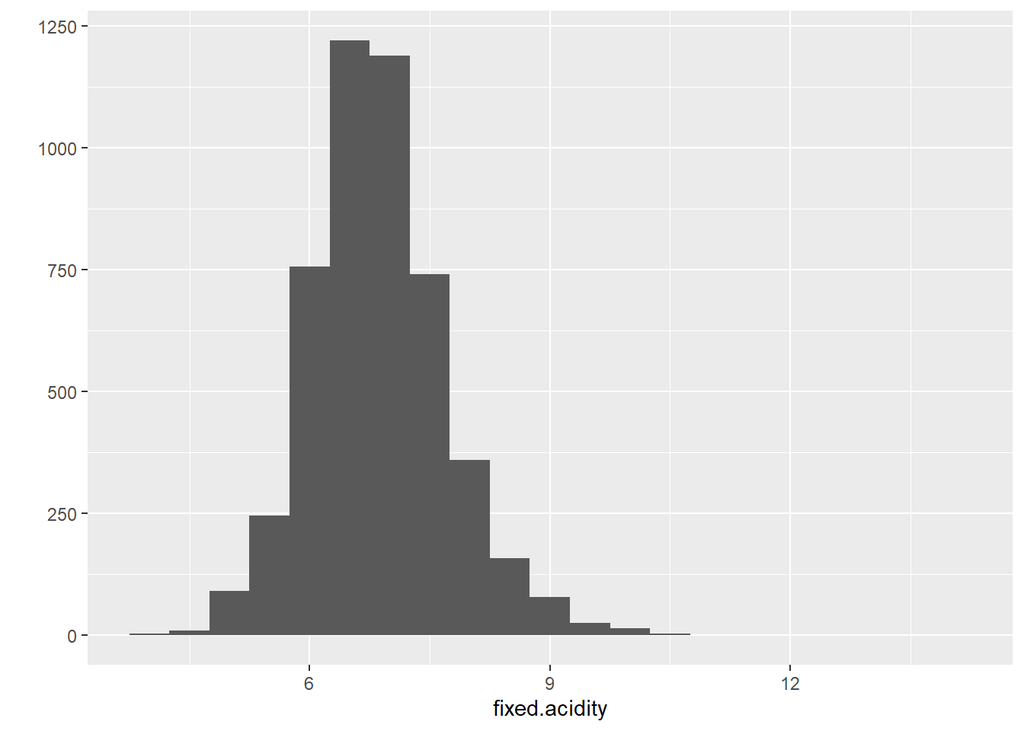

Fixed.acidity has a normal distribution.

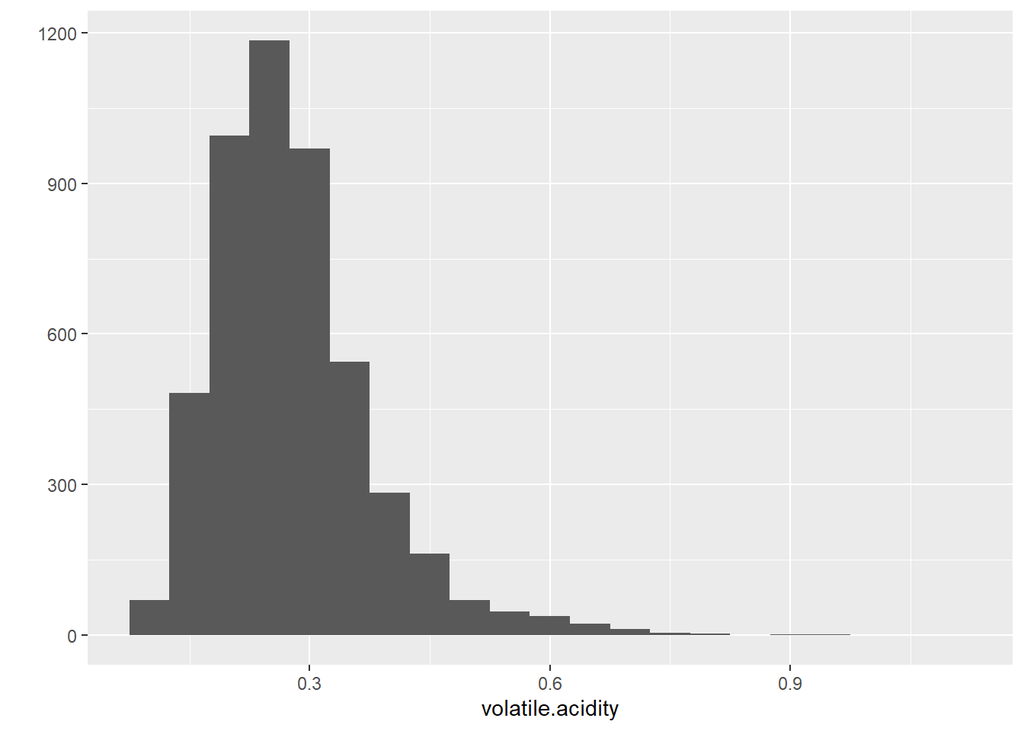

Volatile.acidity has a relatively normal distribution.

Some domain research has helped me understand that fixed acidity is a formula of total acidity minus volatile acidity. In this dataset, we are keeping track of both fixed.acidity and volatile.acidity, so we should we able to calculate a new variabled called total.acidity.

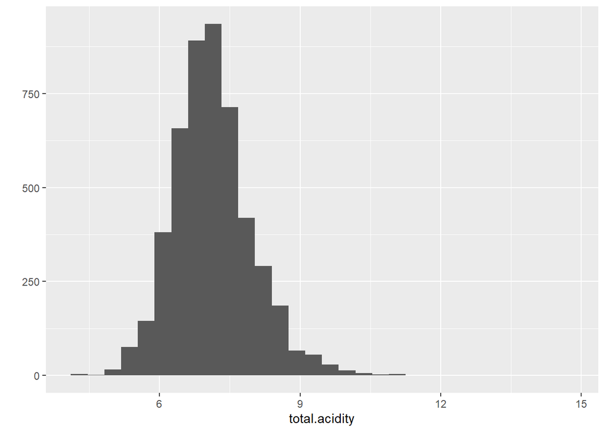

As expected, there is also a normal distribution for total.acidity.

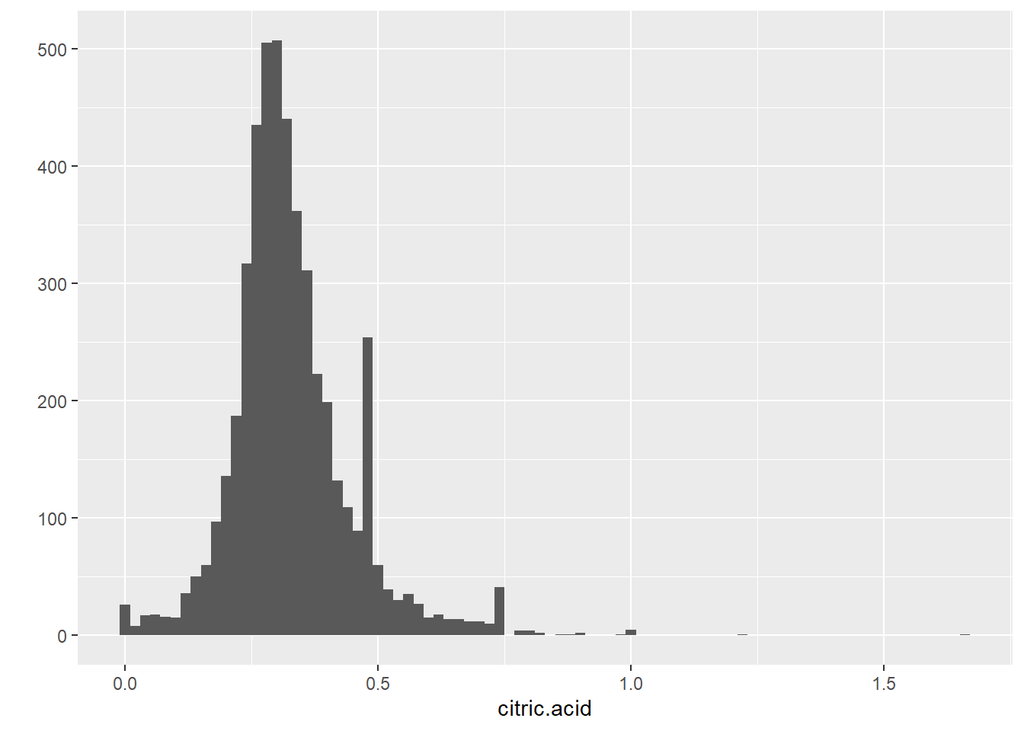

Citric.acid appears to have a couple of different peaks that I might be interested in diving into more.

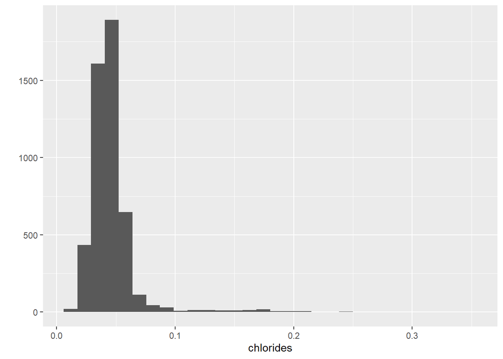

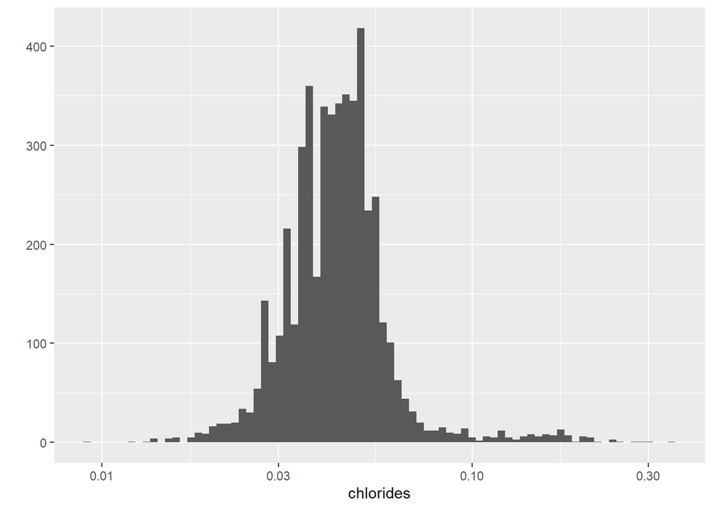

After updating the plot with a log10 x value, I get a more normal distribution, but there are a couple of interesting peaks and valleys.

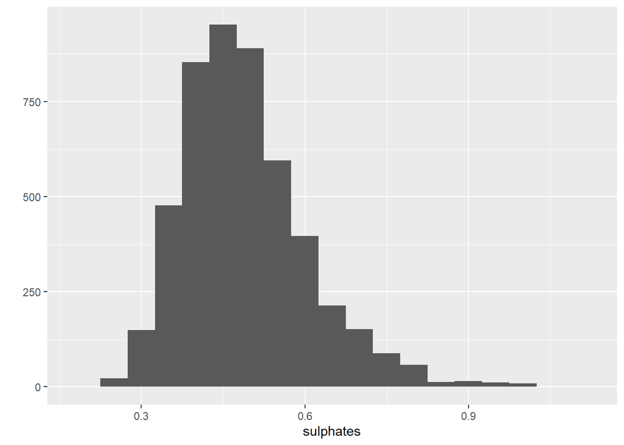

Sulphates have a normal distribution.

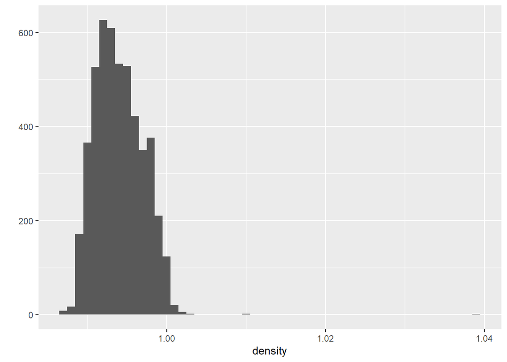

Density appears to have a normal distribution as well, with a couple of outliers.

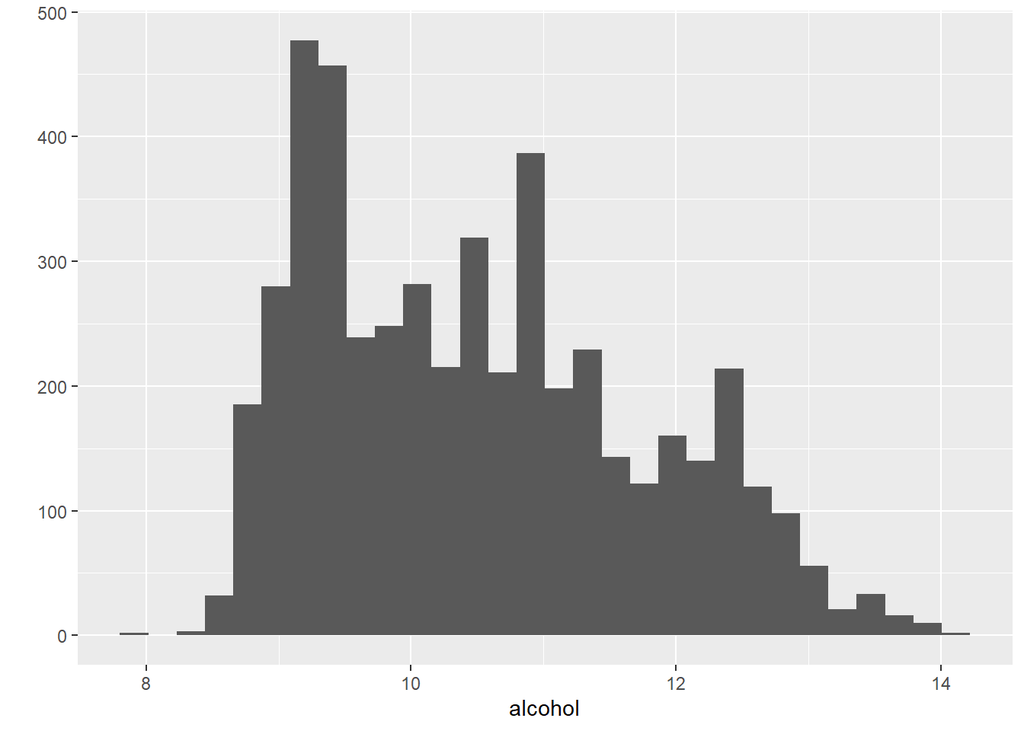

Updating the binwidth to get a better idea of the distribution for alcohol level. I found that using a binwidth of .1 works well since the alcohol value generally has one decimal.

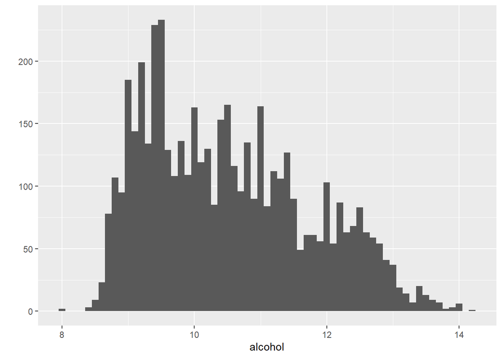

I’m not quite sure if this would be considered multimodal or not. There are quite a lot of peaks and valleys in the distribution of alcohol levels. I will definitely want to keep diving into the connection between alcohol level and quality in my later analyses.

# Univariate Analysis

### What is the structure of your dataset?

Observations: - These wines range in quality scores from 3 - 9, with 6 being the median and mode score. - The amount of residual.sugar can be used to calculate the type of wine (ranging from “Dry” to “Medium Sweet”). - Most of the chemical properties have normal distributions. - The alcohol content has a varied distribution that I want to dig into more.

### What are the main features of interest in your dataset?

I’m interested in diving into Alcohol level affecting quality. I want to see how these fit in with other chemical properties. I’m still interested in residual.sugar and how that fits in as well.

### What other features in the dataset do you think will help support your investigation into your feature(s) of interest?

Domain research has shown that acidity and pH work together to create flavor and texture. I want to see how these variables interact. Domain research shows that acidity is a big part of the taste. Too little acidity leads to dull, flat, boring taste.

### Did you create any new variables from existing variables in the dataset?

I created a categorical value of type based on the residual.sugar variable. I also created a value total.acidity which is a sum of fixed.acidity and volatile.acidity.

### Of the features you investigated, were there any unusual distributions? Did you perform any operations on the data to tidy, adjust, or change the form of the data? If so, why did you do this?

There were unusual distributions with residual.sugar and alcohol. For residual.sugar, I was able to create a new variable called type to use as a categorical variable. It turns out that most of the wines studied were of a “dry” or “off dry” type. I played around with binwidth on a lot of the variables to get a better idea of the distributions. For chlorides, I ended up using a log10 for the x axis, which helped provide me with a much more normal distribution.

# Bivariate Plots Section

Now I’d like to look further into possible relationships between the different variables. I start out with a correlation matrix and visualization to help see what statistics might be more closely related to one another.

```
##                      fixed.acidity volatile.acidity citric.acid residual.sugar
## fixed.acidity                 1.00            -0.02        0.29           0.09
## volatile.acidity             -0.02             1.00       -0.15           0.06
## citric.acid                   0.29            -0.15        1.00           0.09
## residual.sugar                0.09             0.06        0.09           1.00
## chlorides                     0.02             0.07        0.11           0.09
## free.sulfur.dioxide          -0.05            -0.10        0.09           0.30
## total.sulfur.dioxide          0.09             0.09        0.12           0.40
## density                       0.27             0.03        0.15           0.84
## pH                           -0.43            -0.03       -0.16          -0.19
## sulphates                    -0.02            -0.04        0.06          -0.03
## alcohol                      -0.12             0.07       -0.08          -0.45
## quality                      -0.11            -0.19       -0.01          -0.10
## total.acidity                 0.99             0.10        0.27           0.10
##                      chlorides free.sulfur.dioxide total.sulfur.dioxide density
## fixed.acidity             0.02               -0.05                 0.09    0.27
## volatile.acidity          0.07               -0.10                 0.09    0.03
## citric.acid               0.11                0.09                 0.12    0.15
## residual.sugar            0.09                0.30                 0.40    0.84
## chlorides                 1.00                0.10                 0.20    0.26
## free.sulfur.dioxide       0.10                1.00                 0.62    0.29
## total.sulfur.dioxide      0.20                0.62                 1.00    0.53
## density                   0.26                0.29                 0.53    1.00
## pH                       -0.09                0.00                 0.00   -0.09
## sulphates                 0.02                0.06                 0.13    0.07
## alcohol                  -0.36               -0.25                -0.45   -0.78
## quality                  -0.21                0.01                -0.17   -0.31
## total.acidity             0.03               -0.06                 0.10    0.27
##                         pH sulphates alcohol quality total.acidity
## fixed.acidity        -0.43     -0.02   -0.12   -0.11          0.99
## volatile.acidity     -0.03     -0.04    0.07   -0.19          0.10
## citric.acid          -0.16      0.06   -0.08   -0.01          0.27
## residual.sugar       -0.19     -0.03   -0.45   -0.10          0.10
## chlorides            -0.09      0.02   -0.36   -0.21          0.03
## free.sulfur.dioxide   0.00      0.06   -0.25    0.01         -0.06
## total.sulfur.dioxide  0.00      0.13   -0.45   -0.17          0.10
## density              -0.09      0.07   -0.78   -0.31          0.27
## pH                    1.00      0.16    0.12    0.10         -0.43
## sulphates             0.16      1.00   -0.02    0.05         -0.02
## alcohol               0.12     -0.02    1.00    0.44         -0.11
## quality               0.10      0.05    0.44    1.00         -0.14
## total.acidity        -0.43     -0.02   -0.11   -0.14          1.00
```

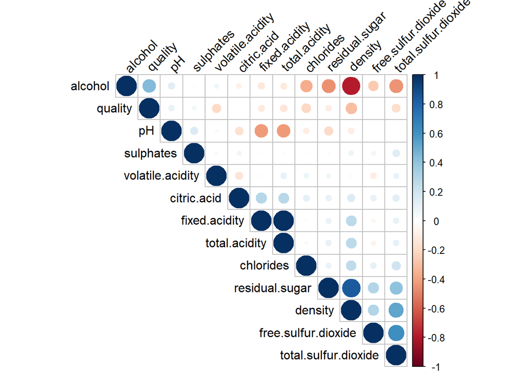

Through domain research, I’ve learned that if a wine has a high acid level, it will have a low pH, which gives the wine a much better chance at discouraging growth of bacteria. At the same time, a low acidity with a high pH can cause a “flabby or almost soapy feeling” to the flavor.

```
##
##  Pearson's product-moment correlation
##
## data:  wine$total.acidity and wine$pH
## t = -33.116, df = 4896, p-value < 2.2e-16
## alternative hypothesis: true correlation is not equal to 0
## 95 percent confidence interval:
##  -0.4503932 -0.4046240
## sample estimates:
##        cor
## -0.4277827
```

There is some negative correlation between pH and total.acidity, which makes sense according to what I’ve learned about the way those chemicals work together in wine.

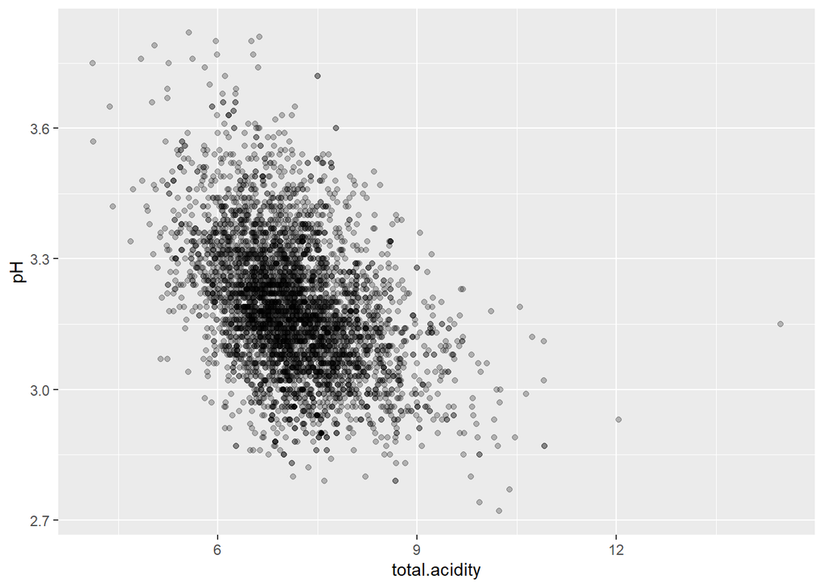

It is possible to see the negative correlation between pH and total.acidity.

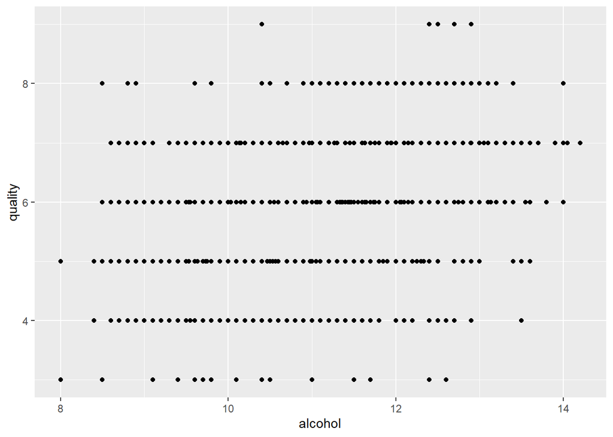

I realized that using quality as a numerical value was not very useful. Since the values were all integers and there are only several options, I decided to turn it into a factor so I could use it as a categorical variable.

I could then create bivariate plots looking at the quality and chemical variables.

```
##
##  Pearson's product-moment correlation
##
## data:  wine$alcohol and wine$quality
## t = 33.858, df = 4896, p-value < 2.2e-16
## alternative hypothesis: true correlation is not equal to 0
## 95 percent confidence interval:
##  0.4126015 0.4579941
## sample estimates:
##       cor
## 0.4355747
```

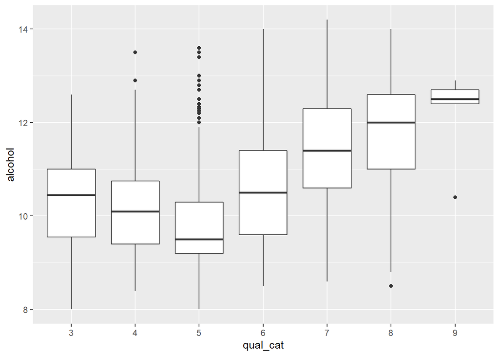

Now I can see that there is an interesting trend with the quality and alcohol level. After a certain point, the alcohol level goes up with the quality level going up.

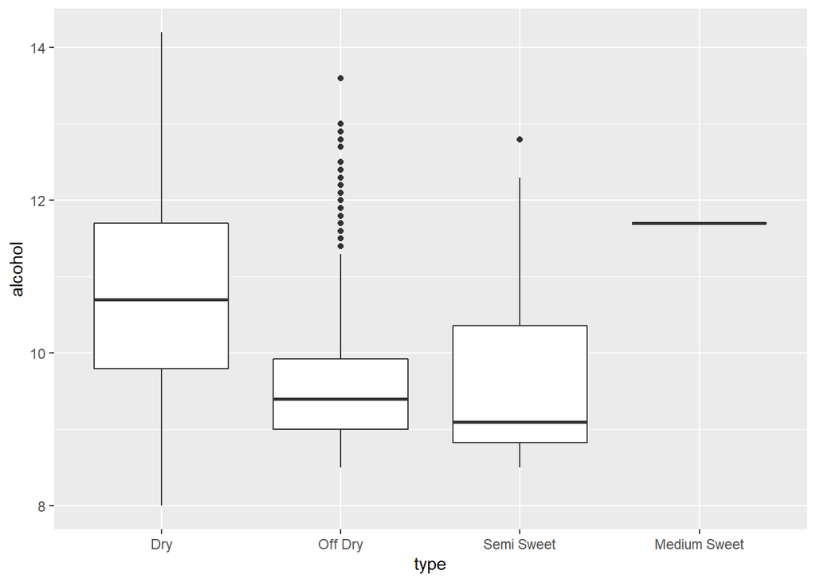

There appears to be a difference in alcohol level of the different wine types.

```
##
##  Pearson's product-moment correlation
##
## data:  wine$residual.sugar and wine$quality
## t = -6.8603, df = 4896, p-value = 7.724e-12
## alternative hypothesis: true correlation is not equal to 0
## 95 percent confidence interval:
##  -0.12524103 -0.06976101
## sample estimates:
##         cor
## -0.09757683
```

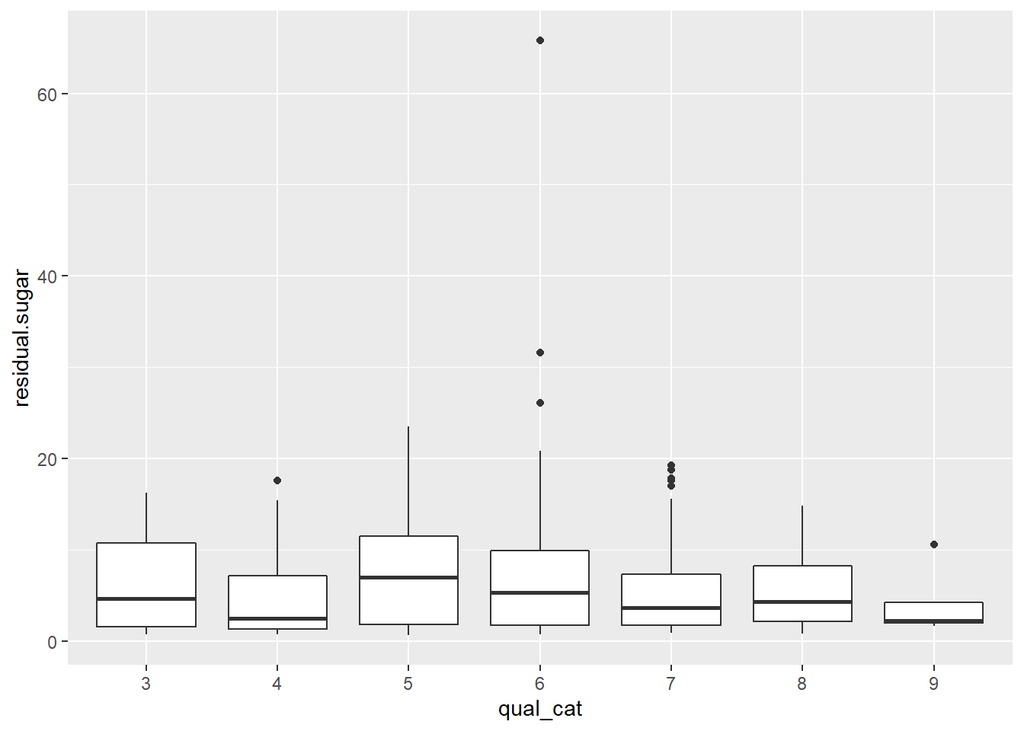

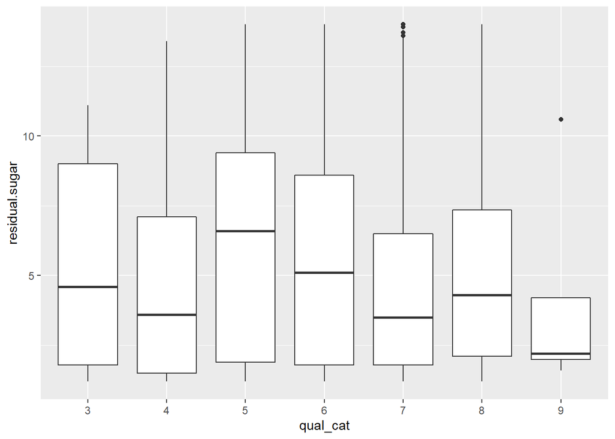

I don’t see any specific trends with quality and residual.sugar directly.

```
##
##  Pearson's product-moment correlation
##
## data:  wine$residual.sugar and wine$density
## t = 107.87, df = 4896, p-value < 2.2e-16
## alternative hypothesis: true correlation is not equal to 0
## 95 percent confidence interval:
##  0.8304732 0.8470698
## sample estimates:
##       cor
## 0.8389665
```

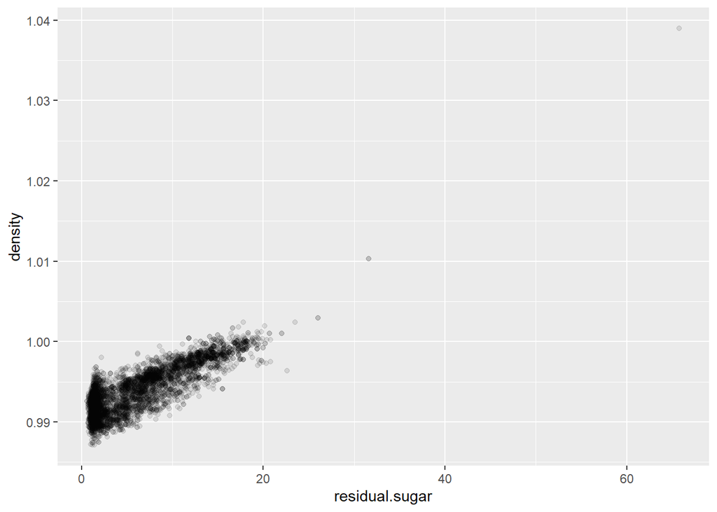

There does appear to be a trend with residual.sugar and density, so I decided to update the scatterplot to focus in more on the data.

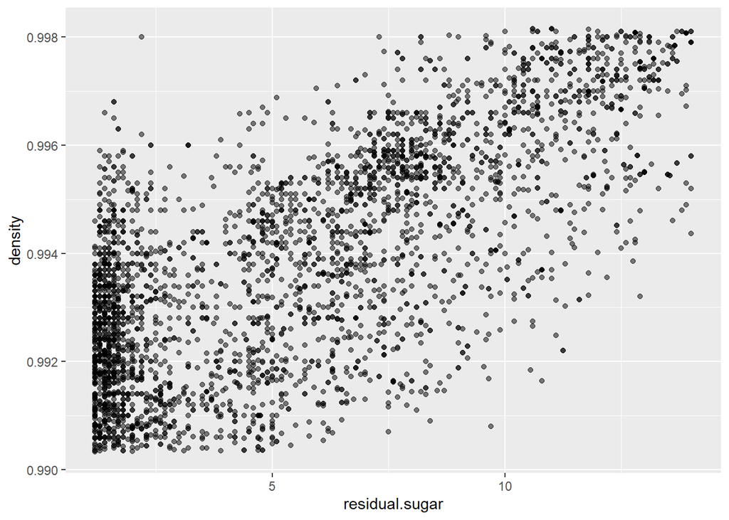

There is a high correlation between residual.sugar and density.

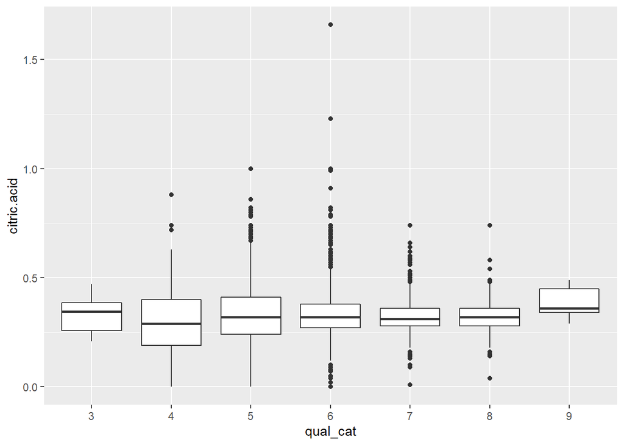

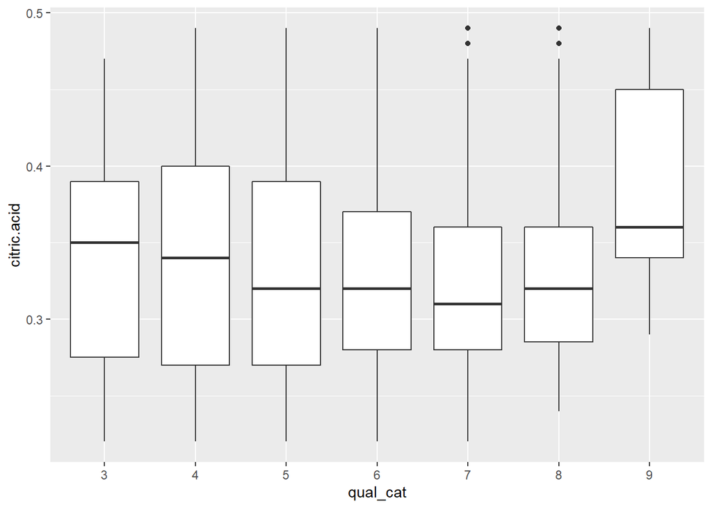

```
##
##  Pearson's product-moment correlation
##
## data:  wine$citric.acid and wine$quality
## t = -0.6444, df = 4896, p-value = 0.5193
## alternative hypothesis: true correlation is not equal to 0
## 95 percent confidence interval:
##  -0.03720595  0.01880221
## sample estimates:
##          cor
## -0.009209091
```

There doesn’t appear to be a direct correlation between citric.acid and quality.

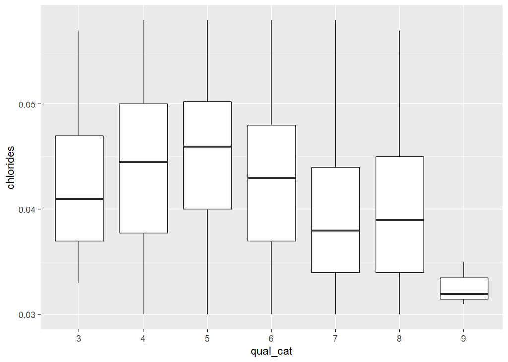

```
##
##  Pearson's product-moment correlation
##
## data:  wine$chlorides and wine$quality
## t = -15.024, df = 4896, p-value < 2.2e-16
## alternative hypothesis: true correlation is not equal to 0
## 95 percent confidence interval:
##  -0.2365501 -0.1830039
## sample estimates:
##        cor
## -0.2099344
```

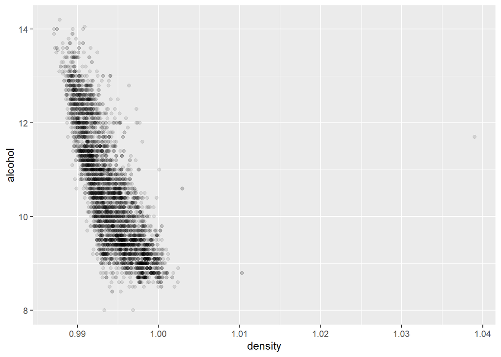

```
##
##  Pearson's product-moment correlation
##
## data:  wine$alcohol and wine$density
## t = -87.255, df = 4896, p-value < 2.2e-16
## alternative hypothesis: true correlation is not equal to 0
## 95 percent confidence interval:
##  -0.7908646 -0.7689315
## sample estimates:
##        cor
## -0.7801376
```

There does appear to be a negative correlation between alcohol level and density.

# Bivariate Analysis

### Talk about some of the relationships you observed in this part of the investigation. How did the feature(s) of interest vary with other features in the dataset?

Looking at the various chemical properties compared to quality was interesting. I found that the mean alcohol level did seem to increase with the quality rating of the wine after a quality rating of 5 and above. There is some positive correlation there; however, I believe that there are other factors that need to be considered.

It was interesting to see that some of the chemical properties like chlorides and citric.acid did not have much correlation with the quality rating.

### Did you observe any interesting relationships between the other features (not the main feature(s) of interest)?

There is negative correlation between pH and total.acidity, which makes sense after doing domain research. The higher the total.acidity, the lower the pH. There was also a strong positive correlation between residual.sugar and density, as well as a strong negative correlation between alcohol level and density.

### What was the strongest relationship you found?

The strongest correlation appeared to be between residual.sugar and density.